# Statistical Rethinking Chapter 3: Sampling the Imaginary

### Introduction

Vampire example:

$$Pr(\text{vampire|positive}) =
\frac{Pr(\text{positive|vampire})Pr(\text{vampire})}{Pr(\text{positive|vampire})+Pr(\text{positive|mortal})(1-Pr(\text{vampire}))}$$
$$=\frac{0.95*0.001}{(0.95*0.001) +
(0.01*(1-0.001))}$$
Code to calculate:

```r
Pr_positive_vampire <- 0.95
Pr_positive_mortal <- 0.01
Pr_vampire <- 0.001
Pr_Positive <- Pr_positive_vampire*Pr_vampire + Pr_positive_mortal*(1-Pr_vampire)
( Pr_vampire_positive <- Pr_positive_vampire*Pr_vampire/Pr_Positive)
```

```
[1] 0.08683729
```

Shows that when the condition of interest is very rare, having a test that finds the true cases is no guarantee that the positive result carries much information since most are false positives

Can use counts to display the same information:

$$Pr(\text{vampire|positive})=\frac{95}{1094} = 0.087$$
This is called the *frequency format* or *natural frequencies*.

Thinking Bayesian -> we can exploit this format by taking probability distributions and sampling from them to produce counts

- Can also draw samples from the posterior distribution -> sampled events are parameter values

### 3.1 Sampling from a grid-approximate posterior

Before we sample from the posterior, we need to make one. Using the Globe tossing model and grid approximation let’s create the posterior:

```r
p_grid <- seq(from=0, to=1, length.out=1000)
prob_p <- rep(1, 1000) # prior
prob_data <- dbinom(6, size=9, prob=p_grid)
posterior <- prob_data * prob_p
posterior <- posterior/sum(posterior)
```

Now we want to draw 10000 samples from this posterior * Imagine the posterior is a bucket full of parameters values, with each value existing in proportion to the posterior probability in `posterior` * We can sample from this bucket to approximate the posterior

```r
samples <- sample(p_grid, prob=posterior, size=1e4, replace=TRUE)
```

Lets plot the samples and the *density estimate* using the `dens()` function from `rethinking`

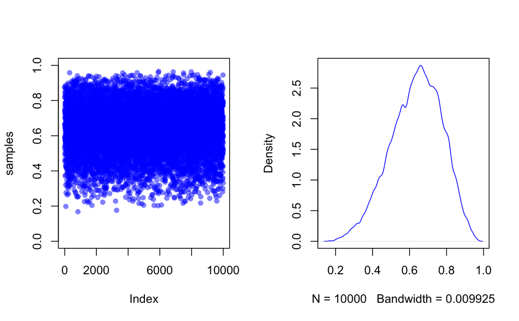

```r
par(mfrow=c(1,2))
plot(samples, col=rgb(0, 0, 1, alpha = 0.5), pch=16, ylim=c(0,1))
dens(samples, col='blue')
```

### 3.2 Sampling to summarize

How do you summarize the posterior? Common questions include:

1. Questions about intervals of *defined boundaries*
- How much posterior probability lies below some parameter value?
- How much posterior probability lies between two parameters values?
2. Questions about intervals of *defined probability mass*
- Which parameter value marks the lower 5% of the posterior probability?
- Which range of parameter values contains 90% of the posterior probability?
3. Questions about *point estimates*
- Which parameter value has highest posterior probability?

#### 3.2.1 Intervals of defined boundaries

What is the posterior probability that the proportion of water is less than 0.5

```r
# Add up posterior probability where p < 0.5
sum(posterior[p_grid<0.5])
```

```
[1] 0.1718746
```

This is the way to do it for single parameters with grid approximation -> trickier when more parameters present

The same calculation using samples from the posterior can be computed as the proportion (or frequency) of samples that match your criteria:

```r
sum(samples < 0.5)/length(samples)
```

```
[1] 0.1731
```

This is generalizable to instances with more than one parameter as well. It can also be used to find how much of the posterior probability lies between 0.5 and 0.75:

```r
sum(samples > 0.5 & samples < 0.75)/length(samples)
```

```
[1] 0.6053
```

#### 3.2.2 Intervals of defined mass

Intervals of defined mass - or *confidence intervals* or *credibility intervals* or *compatibility intervals* - are ranges of parameter values compatible with the model and data.

- Report two parameter values that contain between them a specified amount of posterior probability, which is a probability mass.

To find the lower 80% posterior probability use `quantile()`

```r
quantile(samples, 0.8)
```

```
      80%
0.7587588
```

To find the middle 80% find the parameter values at the 10th and 90th percentiles

```r
quantile( samples, c(0.1, 0.9))
```

```
      10%       90%
0.4454454 0.8108108
```

These types of intervals, where equal probability mass is assigned to each tail, can also be called *percentile intervals (PI)*. However, it isn’t perfect, consider the following posterior distribution:

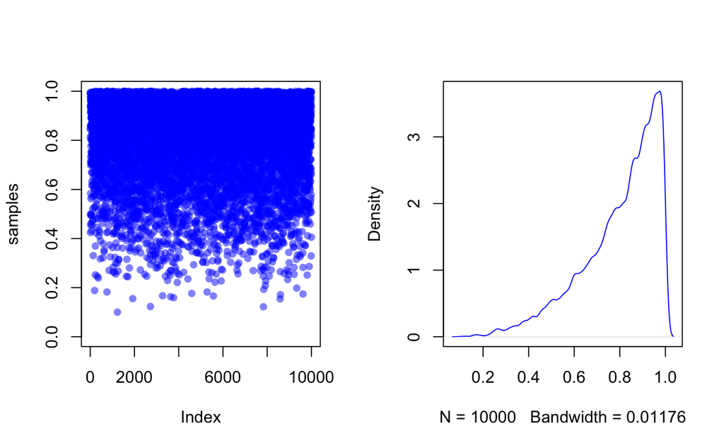

```r
p_grid <- seq(from=0, to=1, length.out=1000)
prior <- rep(1,1000)
likelihood <- dbinom(3, size=3, prob=p_grid)
posterior <- likelihood*prior
posterior <- posterior / sum(posterior)
samples <- sample(p_grid, size=1e4, replace=TRUE, prob=posterior)

par(mfrow=c(1,2))

plot(samples, col=rgb(0, 0, 1, alpha = 0.5), pch=16, ylim=c(0,1))
dens(samples, col='blue')
```

You can use `PI()` from `rethinking` to calculate middle intervals:

```r
PI(samples, prob=0.5)
```

```
      25%       75%
0.7077077 0.9299299
```

This puts 25% of the probability mass above and below the interval, but excludes the most probable parameter values near p=1, misleading information on the shape of the distribution.

Instead you can use the *highest posterior density interval* (HPDI) - the narrowest interval containing the specified probability mass. You can calculate it using `HPDI()` from `rethinking`

```r
HPDI(samples, prob=0.5)
```

```
     |0.5      0.5|
0.8468468 1.0000000
```

Disadvantages of HPDI: 1. More computationally intensive 2. Suffers from greater simulation variance 3. Harder to understand